# CP05

Jose López Galdón

2020-11-20

## PLANTEAMIENTO

En general, a los directores de marketing les gustaría conocer la efectividad de sus gastos en publicidad. El análisis de intervención proporciona una herramienta que puede ser útil para evaluar el impacto de las iniciativas que la empresa, los competidores o terceros pueden realizar en el mix de mercado. En esta caso práctico, consideramos la lucha por la cuota de mercado entre la crema dental Colgate de Colgate-Palmolive y la crema dental Crest de Procter y Gamble.

Procter y Gamble introdujeron Crest en el mercado estadounidense en 1956. Antes de ese momento, Colgate disfrutaba de un liderazgo de mercado con una participación de mercado cercana al 50%. Durante los siguientes 4 años, Colgate siguió siendo un competidor dominante y Crest solo logró una participación de mercado relativamente modesta pero estable del 15%. Sin embargo, el 1 de agosto de 1960, el Consejo de Terapéutica Dental de la American Dental Association (ADA) aprobó a Crest como una “ayuda importante en cualquier programa de higiene dental”.

Mientras tanto, Procter y Gamble revitalizaron su campaña de marketing para aprovechar el respaldo de la ADA, lo que dio como resultado un salto casi inmediato en la cuota de mercado de Crest en detrimento de la de Colgate.

## OBJETIVO

El objetivo es predecir las 16 semanas del año 1963, para las dos cuotas de mercado, por lo que se dejará fuera de la muestra este periodo muestral.

El análisis debe incluir para las dos series la estimación de un modelo ARIMA, la detección de atípicos/outlier y un modelo de interveción. Por último se debe realizar un modelo de función de tranferencia entre las dos cuotas.

Comenzaremos visualizando los datos que tenemos, como podemos observar tenemos 4 columnas:

- `Year`: Año
- `Week`: Semana
- `Crest`: Cuota de mercado para compañía Crest
- `Colgate`: Cuota de mercado de Colgate.

```r
head(raw_data, 10)
```

```
## # A tibble: 10 x 4
##     Year  Week Crest Colgate
##    <dbl> <dbl> <dbl>   <dbl>
##  1  1958     1 0.108   0.424
##  2  1958     2 0.166   0.482
##  3  1958     3 0.126   0.428
##  4  1958     4 0.115   0.397
##  5  1958     5 0.119   0.352
##  6  1958     6 0.176   0.342
##  7  1958     7 0.155   0.434
##  8  1958     8 0.118   0.445
##  9  1958     9 0.136   0.428
## 10  1958    10 0.137   0.395
```

## EDA

Comenzaremos realizando un breve análisis exploratorio de los datasets.

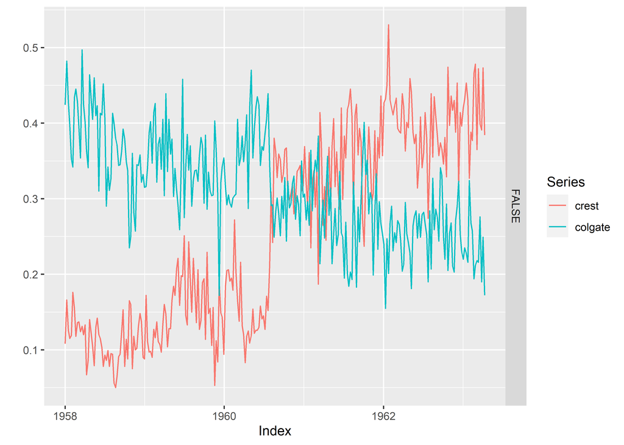

Gracias a este gráfico somos capaces de ver como se ha produciddo un cambio en la cuota de mercado de los dentífrico. Hasta mitades de 1960 se produce un cambio y vemos como COLGATE pierde la posición dominante en pro de CREST ¿Por qué?

El 1 de agosto de 1960, el Consejo de Terapéutica Dental de la *American Dental Association* (ADA) aprobó a CREST como una “ayuda importante en cualquier programa de higiene dental”.

Mientras tanto, *Procter y Gamble* revitalizaron su campaña de marketing para aprovechar el respaldo de la ADA, lo que dio como resultado un salto casi inmediato en la cuota de mercado de CREST en detrimento de la de COLGATE.

Por lo tanto, podemos observar cómo se produce un cambio en la serie temporal.

## ARIMA

### Crest

Comenzamos con la compañía CREST

```r
arima_crest <- auto.arima(o_crest)

summary(arima_crest)
```

```
## Series: o_crest
## ARIMA(0,1,1)
##
## Coefficients:
##           ma1
##       -0.6377
## s.e.   0.0471
##
## sigma^2 estimated as 0.05107:  log likelihood=17.94
## AIC=-31.89   AICc=-31.84   BIC=-24.77
##
## Training set error measures:
##                      ME      RMSE       MAE       MPE     MAPE      MASE
## Training set 0.01269669 0.2251133 0.1683403 -2.528429 11.28135 0.1083138
##                      ACF1
## Training set -0.006409037
```

```
##       Point Forecast     Lo 80      Hi 80     Lo 95      Hi 95
## -2563     -0.9353508 -1.224961 -0.6457405 -1.378272 -0.4924300
## -2556     -0.9353508 -1.243386 -0.6273157 -1.406450 -0.4642517
## -2549     -0.9353508 -1.260769 -0.6099324 -1.433035 -0.4376662
## -2542     -0.9353508 -1.277270 -0.5934317 -1.458271 -0.4124306
## -2535     -0.9353508 -1.293010 -0.5776915 -1.482344 -0.3883580
## -2528     -0.9353508 -1.308086 -0.5626153 -1.505401 -0.3653011
## -2521     -0.9353508 -1.322576 -0.5481258 -1.527561 -0.3431412
## -2514     -0.9353508 -1.336543 -0.5341591 -1.548921 -0.3217811
## -2507     -0.9353508 -1.350039 -0.5206626 -1.569562 -0.3011400
## -2500     -0.9353508 -1.363110 -0.5075918 -1.589552 -0.2811498
## -2493     -0.9353508 -1.375793 -0.4949086 -1.608949 -0.2617526
## -2486     -0.9353508 -1.388121 -0.4825806 -1.627803 -0.2428986
## -2479     -0.9353508 -1.400122 -0.4705795 -1.646157 -0.2245444
## -2472     -0.9353508 -1.411821 -0.4588806 -1.664049 -0.2066525
## -2465     -0.9353508 -1.423240 -0.4474621 -1.681512 -0.1891894
## -2458     -0.9353508 -1.434397 -0.4363048 -1.698576 -0.1721258
```

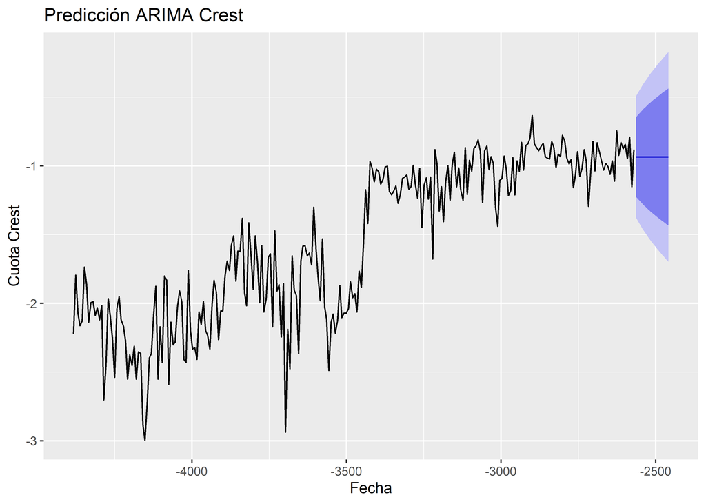

Obtenemos una precisión incorrecta debido al salto en la serie temporal.

### Colgate

Continuamos con la predicción para COLGATE.

```r
arima_colgate <- auto.arima(o_colgate)

summary(arima_colgate)
```

```
## Series: o_colgate
## ARIMA(0,1,1)
##
## Coefficients:
##           ma1
##       -0.7688
## s.e.   0.0480
##
## sigma^2 estimated as 0.02572:  log likelihood=106.6
## AIC=-209.2   AICc=-209.15   BIC=-202.08
##
## Training set error measures:
##                        ME      RMSE      MAE        MPE     MAPE      MASE
## Training set -0.008080012 0.1597463 0.123498 -0.8343985 10.59627 0.1055543
##                    ACF1
## Training set 0.04624703
```

```
##       Point Forecast     Lo 80     Hi 80     Lo 95      Hi 95
## -2563      -1.330718 -1.536234 -1.125203 -1.645027 -1.0164103
## -2556      -1.330718 -1.541655 -1.119782 -1.653318 -1.0081192
## -2549      -1.330718 -1.546940 -1.114497 -1.661401 -1.0000359
## -2542      -1.330718 -1.552099 -1.109338 -1.669291 -0.9921455
## -2535      -1.330718 -1.557141 -1.104296 -1.677002 -0.9844349
## -2528      -1.330718 -1.562073 -1.099364 -1.684545 -0.9768923
## -2521      -1.330718 -1.566902 -1.094535 -1.691930 -0.9695072
## -2514      -1.330718 -1.571634 -1.089803 -1.699167 -0.9622700
## -2507      -1.330718 -1.576275 -1.085162 -1.706265 -0.9551723
## -2500      -1.330718 -1.580830 -1.080607 -1.713231 -0.9482063
## -2493      -1.330718 -1.585303 -1.076134 -1.720072 -0.9413648
## -2486      -1.330718 -1.589699 -1.071738 -1.726795 -0.9346416
## -2479      -1.330718 -1.594022 -1.067415 -1.733406 -0.9280305
## -2472      -1.330718 -1.598275 -1.063162 -1.739911 -0.9215263
## -2465      -1.330718 -1.602461 -1.058976 -1.746313 -0.9151238
## -2458      -1.330718 -1.606584 -1.054853 -1.752618 -0.9088185
```

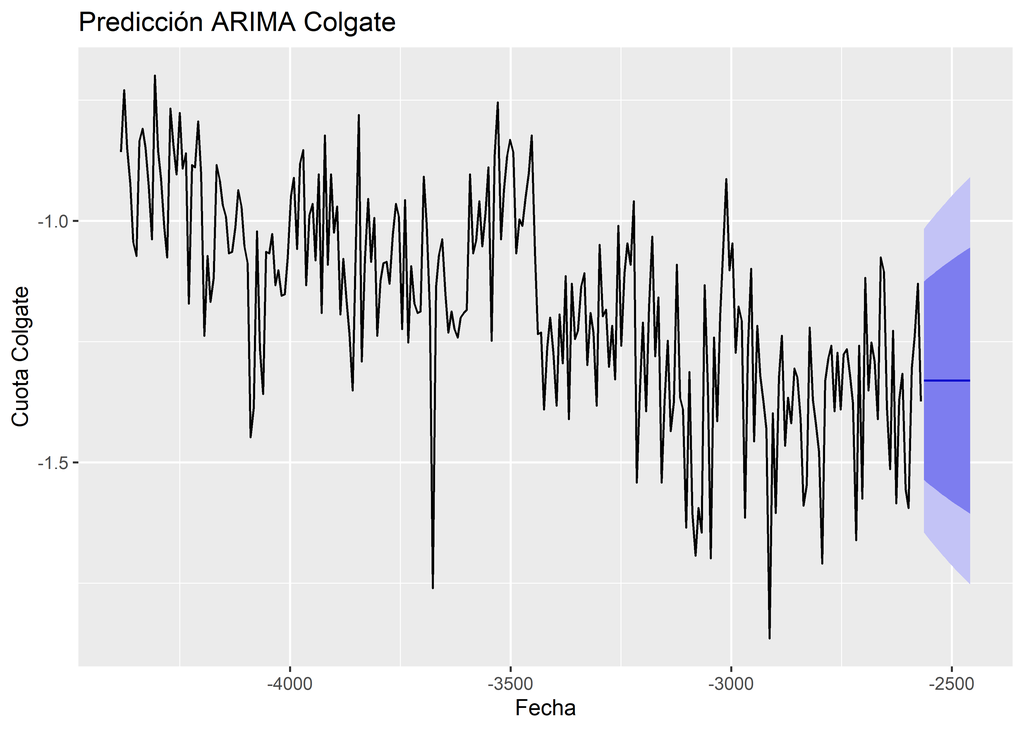

La predicción sale incorrecta debido a que tenemos un cambio en la serie temporal.

## Detección de outliers

Como tenemos problemas por culpa del cambio producido en la serie temporal (recordemos que se debe a que la ADA aprobó el 1 de Agosto de 1960 a Crest como una marca importante en cualquier tratamiento de higiene dental) comenzaremos analizando los *outliers* en la serie:

A título teórico, sabemos que existen dos tipos de *outliers*:

- **Aditivos (AO)**: Afectan a la serie temporal
- **Innovativos (IO)**: Afectan al error

## Modelo de intervención

### Predicción cuotas de mercado

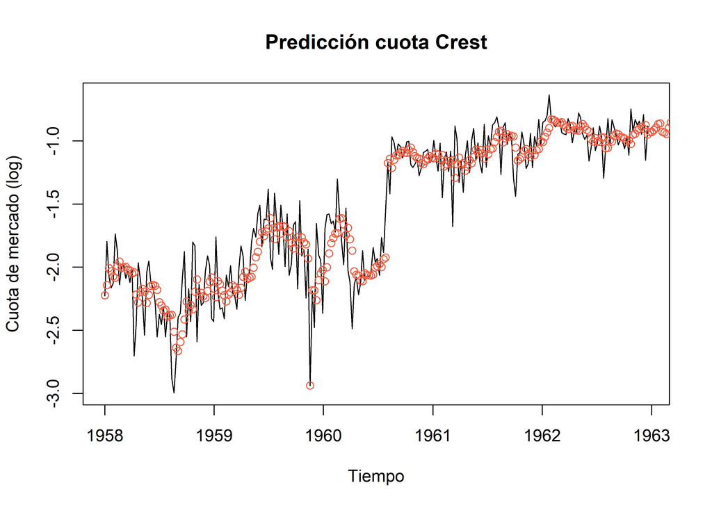

Como podemos observar el modelo se ajusta correctamente a la serie temporal y tenemos la predicción para el año 1963. Podemos observar como la predeicción estima un ligero creciemiento a partir del 63, pero prácticamente constante.

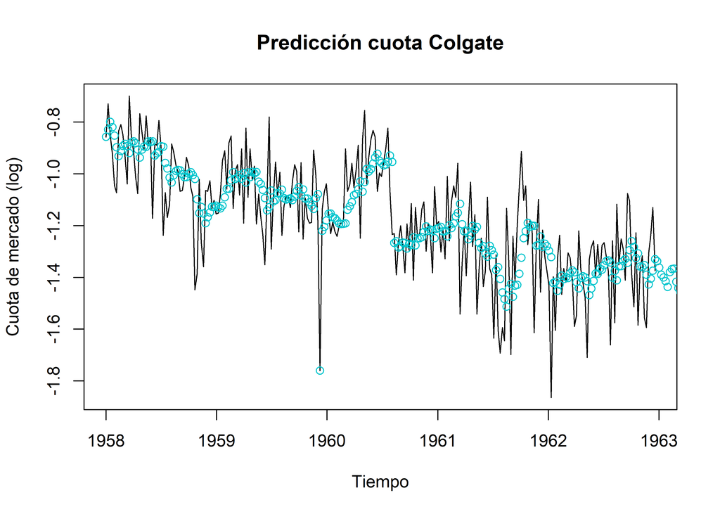

En el caso de Colgate el modelo también se ajusta bastante a la serie temporal, y vemos como la predicción es que siga perdiendo cuota…

## Función de transferencia

Si queremos estudiar el impacto de la noticia de ADA en Colgate, utilizaremos la función de trasferencia.